# Codebook for df

Autogenerated data summary from dataMaid

2022-01-23 23:33:07

# Data report overview

The dataset examined has the following dimensions:

| Feature | Result |
| --- | --- |
| Number of observations | 784 |
| Number of variables | 10 |

# Codebook summary table

| Label | Variable | Class | # unique values | Missing | Description |
| --- | --- | --- | --- | --- | --- |
|  | **X** | integer | 784 | 0.00 % |  |
|  | **course** | character | 771 | 0.00 % |  |
|  | **Link** | character | 639 | 1.40 % |  |
|  | **Introduction** | character | 480 | 0.00 % |  |
|  | **Address** | character | 76 | 0.00 % |  |
|  | **Contact** | character | 110 | 0.00 % |  |
|  | **Duration** | integer | 6 | 16.84 % |  |
|  | **Fee** | integer | 118 | 17.09 % |  |
|  | **uni_name** | character | 16 | 0.00 % |  |
|  | **Fac_link** | character | 15 | 0.00 % |  |

# Variable list

## X

| Feature | Result |
| --- | --- |
| Variable type | integer |
| Number of missing obs. | 0 (0 %) |
| Number of unique values | 784 |
| Median | 392.5 |
| 1st and 3rd quartiles | 196.75; 588.25 |
| Min. and max. | 1; 784 |

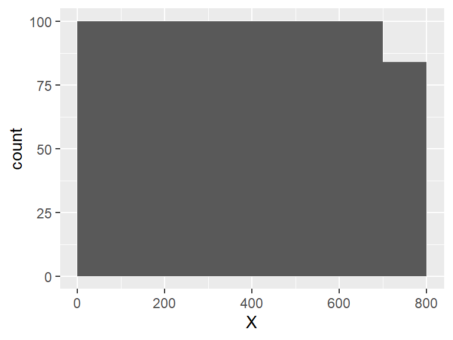

## course

| Feature | Result |
| --- | --- |
| Variable type | character |
| Number of missing obs. | 0 (0 %) |
| Number of unique values | 771 |
| Mode | “Bachelor of Computer Science (Software Engineering) with Honours” |

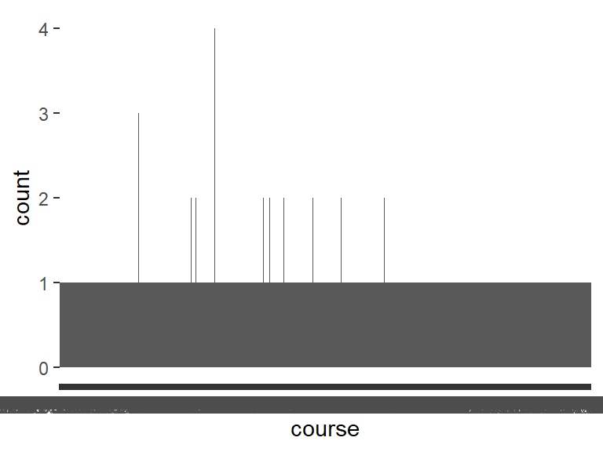